# Experiences in Long-Distance Romantic Relationship

- Show All Code
- Hide All Code
- View Source

PSY 120L Reproducible Analysis Report

Author

Lilet Martinez

Published

June 1, 2026

## About This Report

This reproducible analysis report demonstrates the data preparation, variable construction, descriptive statistics, primary analyses, and figures for the study.

Therefore, it illustrates how the analyses were produced from the data set using a transparent, reproducible Quarto workflow, examining experiences in long-distance romantic relationships in relation to attachment styles and prior relationship experience.

## Study Overview

This design study examined whether relationship satisfaction varies with communication responsiveness, prior relationship experience, attachment styles, and their interactions.

The design included one manipulated independent variable and two categorical moderators: Communication Responsiveness (High vs. Low) is the independent variable, and Prior Relationship Experience (Prior vs. None) and Attachment Styles (Secure vs. Insecure) are the moderators. While, the dependent variable was relationship satisfaction.

Primary analyses tested whether communication responsiveness, prior relationship experience, and attachment styles and their interaction predicted each outcome.

## Setup and Software Environment

This section shows how the packages were installed and downloaded, and how they were used for data preparation, scale construction, statistical modeling, estimation of marginal means, and figure creation.

**Load Packages**

```r
library(tidyverse)  # data manipulation + plotting
library(psych)      # scale construction + reliability
library(afex)       # ANOVA models + effect sizes
library(emmeans)    # estimated marginal means + confidence intervals
```

## Data Source and Long-Distance Romantic Relationship Analysis Dataset

The data set was imported from the Long Distance Final Project folder, and saved as study_raw so that the original file remained unchanged throughout the report.

Along with this, a smaller analysis data set was then created for the current analyses. The data set contained the study condition variables, demographic variables, relationship assessment items, adult assessment items, dependence items, closeness discomfort items, and anxiety items needed for variable preparation and analysis.

### Import Dataset

```r
study_raw <- read_csv("data/long_distance_data.csv")
```

### Check Imported Dataset

```r
dim(study_raw)
```

```
[1] 167  39
```

```r
names(study_raw)
```

```
 [1] "StartDate"             "EndDate"               "Duration (in seconds)"
 [4] "Finished"              "RecordedDate"          "Consent Form"
 [7] "MC1"                   "RAS1"                  "RAS2"
[10] "RAS3"                  "RAS4"                  "RAS5"
[13] "RAS6"                  "RAS7"                  "AAS1"
[16] "AAS2"                  "AAS3"                  "AAS4"
[19] "AAS5"                  "AAS6"                  "AAS7"
[22] "AAS8"                  "AAS9"                  "AAS10"
[25] "AAS11"                 "AAS12"                 "AAS13"
[28] "AAS14"                 "AAS15"                 "AAS16"
[31] "AAS17"                 "AAS18"                 "age"
[34] "Age_8_TEXT"            "gender"                "Gender _5_TEXT"
[37] "relationship_exp"      "relationship_length"   "condition"
```

```r
head(study_raw)
```

```
# A tibble: 6 × 39
  StartDate  EndDate Duration (in seconds…¹ Finished RecordedDate `Consent Form`
  <chr>      <chr>                    <dbl>    <dbl> <chr>                 <dbl>
1 4/30/26 1… 4/30/2…                    695        1 4/30/26 18:…              1
2 4/30/26 1… 4/30/2…                  12932        1 4/30/26 22:…              1
3 4/30/26 2… 4/30/2…                    707        1 4/30/26 23:…              1
4 4/30/26 1… 4/30/2…                  15216        1 4/30/26 23:…              1
5 5/5/26 18… 5/5/26…                    417        1 5/5/26 19:05              1
6 5/5/26 19… 5/5/26…                    276        1 5/5/26 19:54              1
# ℹ abbreviated name: ¹`Duration (in seconds)`
# ℹ 33 more variables: MC1 <dbl>, RAS1 <dbl>, RAS2 <dbl>, RAS3 <dbl>,
#   RAS4 <dbl>, RAS5 <dbl>, RAS6 <dbl>, RAS7 <dbl>, AAS1 <dbl>, AAS2 <dbl>,
#   AAS3 <dbl>, AAS4 <dbl>, AAS5 <dbl>, AAS6 <dbl>, AAS7 <dbl>, AAS8 <dbl>,
#   AAS9 <dbl>, AAS10 <dbl>, AAS11 <dbl>, AAS12 <dbl>, AAS13 <dbl>,
#   AAS14 <dbl>, AAS15 <dbl>, AAS16 <dbl>, AAS17 <dbl>, AAS18 <dbl>, age <dbl>,
#   Age_8_TEXT <chr>, gender <dbl>, `Gender _5_TEXT` <chr>, …
```

The imported data set was loaded successfully, and confirms the number of rows and columns, and displays the variable names available in the original data set.

### Create Analysis Dataset

```r
study_vars <- c(
  "condition", "age", "gender",


  "MC1",

  "RAS1", "RAS2", "RAS3", "RAS4", "RAS5", "RAS6", "RAS7",

  "AAS1", "AAS2", "AAS3", "AAS4", "AAS5", "AAS6",
  "AAS7", "AAS8", "AAS9", "AAS10", "AAS11", "AAS12",
  "AAS13", "AAS14", "AAS15", "AAS16", "AAS17", "AAS18",

  "relationship_exp",
  "relationship_length"
)

study_data <- study_raw %>%
  select(all_of(study_vars)) %>%
  mutate(
    across(everything(), as.numeric)
  )
```

### Check Analysis Dataset

```r
length(study_vars)
```

```
[1] 31
```

```r
dim(study_data)
```

```
[1] 167  31
```

```r
names(study_data)
```

```
 [1] "condition"           "age"                 "gender"
 [4] "MC1"                 "RAS1"                "RAS2"
 [7] "RAS3"                "RAS4"                "RAS5"
[10] "RAS6"                "RAS7"                "AAS1"
[13] "AAS2"                "AAS3"                "AAS4"
[16] "AAS5"                "AAS6"                "AAS7"
[19] "AAS8"                "AAS9"                "AAS10"
[22] "AAS11"               "AAS12"               "AAS13"
[25] "AAS14"               "AAS15"               "AAS16"
[28] "AAS17"               "AAS18"               "relationship_exp"
[31] "relationship_length"
```

The long-distance romantic relationship analysis data set contains the variables used in this report, including the number of selected variables, the dimensions of the reproducible analysis data set, and the final variable names.

## Variable Preparation

This section prepares the variables used in the primary analyses, with the original imported dataset remaining unchanged, including the prepared variables created in the dataset, study_data.

### Prepare Participant ID and Experimental Condition

```r
study_data <- study_data %>%
  mutate(
    id = row_number(),

    condition = factor(
      condition,
      levels = c(0, 1),
      labels = c("Low", "High")
    ),

    relationship_exp = factor(
      relationship_exp,
      levels = c(0, 1),
      labels = c("No", "Yes")
    ),

    gender = factor(
      gender,
      levels = c(1, 2, 3, 4, 5),
      labels = c(
        "Female",
        "Male",
        "Transgender",
        "Prefer not to say",
        "Other"
      )
    )
  )
```

The experimental condition variables were recoded as a labeled factor for Condition, Relationship Experience, and Gender, resulting in two to five levels for each. Condition and Relationship Experience both have two levels: Low/High and No/Yes. Gender includes five levels: Female, Male, Transgender, Prefer not to say, and Others. As a result, a participant ID variable was created to ensure each row in the analysis dataset had a unique identifier.

### Check Experimental Condition Coding

```r
study_data %>%
  count(condition) %>%
  knitr::kable()
```

| condition | n |
| --- | --- |
| Low | 83 |
| High | 84 |

```r
study_data %>%
  count(relationship_exp) %>%
  knitr::kable()
```

| relationship_exp | n |
| --- | --- |
| No | 71 |
| Yes | 95 |
| NA | 1 |

```r
study_data %>%
  count(gender) %>%
  knitr::kable()
```

| gender | n |
| --- | --- |
| Female | 132 |
| Male | 28 |
| Transgender | 1 |
| Prefer not to say | 1 |
| Other | 4 |
| NA | 1 |

The condition check confirms the number of participants assigned to each communication responsiveness condition and to the relationship experience and gender groups.

### Check Prepared Analysis Dataset

```r
dim(study_data)
```

```
[1] 167  32
```

```r
names(study_data)
```

```
 [1] "condition"           "age"                 "gender"
 [4] "MC1"                 "RAS1"                "RAS2"
 [7] "RAS3"                "RAS4"                "RAS5"
[10] "RAS6"                "RAS7"                "AAS1"
[13] "AAS2"                "AAS3"                "AAS4"
[16] "AAS5"                "AAS6"                "AAS7"
[19] "AAS8"                "AAS9"                "AAS10"
[22] "AAS11"               "AAS12"               "AAS13"
[25] "AAS14"               "AAS15"               "AAS16"
[28] "AAS17"               "AAS18"               "relationship_exp"
[31] "relationship_length" "id"
```

The prepared analysis data set for this report obtains the variables needed for scale construction, descriptive statistics, and primary analyses.

### Reverse-Code Scale Items

Reverse-Code Scale Items were transformed before Relationship Assessment Scale and Adult Attachment Scale scores were computed. The items used a 1-5 response scale, with reverse coding created by subtracting each original item response from 6.

```r
study_data <- study_data %>%
  mutate(
    # Reverse-code RAS items
    # Original scale: 1 to 5
    # Higher recoded scores = higher relationship satisfaction
    RAS4r = 6 - RAS4,
    RAS7r = 6 - RAS7,

    # Reverse-code AAS items
    # Original scale: 1 to 5
    # Higher recoded scores = higher attachment dimension score
    AAS3r  = 6 - AAS3,
    AAS4r  = 6 - AAS4,
    AAS7r  = 6 - AAS7,
    AAS13r = 6 - AAS13,
    AAS14r = 6 - AAS14,
    AAS17r = 6 - AAS17
  )
```

### Check Reverse Coding

```r
study_data %>%
  select(RAS4, RAS4r, RAS7, RAS7r, AAS3, AAS3r, AAS7, AAS7r) %>%
  head(10) %>%
  knitr::kable()
```

| RAS4 | RAS4r | RAS7 | RAS7r | AAS3 | AAS3r | AAS7 | AAS7r |
| --- | --- | --- | --- | --- | --- | --- | --- |
| 4 | 2 | 4 | 2 | 2 | 4 | 4 | 2 |
| 1 | 5 | 1 | 5 | 1 | 5 | 5 | 1 |
| 1 | 5 | 2 | 4 | 4 | 2 | 3 | 3 |
| 3 | 3 | 4 | 2 | 4 | 2 | 4 | 2 |
| 3 | 3 | 3 | 3 | 3 | 3 | 2 | 4 |
| 4 | 2 | 4 | 2 | 5 | 1 | 1 | 5 |
| 2 | 4 | 3 | 3 | 3 | 3 | 2 | 4 |
| 1 | 5 | 1 | 5 | 3 | 3 | 2 | 4 |
| 3 | 3 | 3 | 3 | 3 | 3 | 3 | 3 |
| 5 | 1 | 1 | 5 | 5 | 1 | 4 | 2 |

### Create Scale Scores

The reverse-coding scale shows examples of original and reverse-coded items, where the reverse-coded variables were created before the Relationship Assessment Scale and Adult Attachment Scale were computed.

```r
ras_items <- c("RAS1", "RAS2", "RAS3", "RAS4r", "RAS5", "RAS6", "RAS7r")

aas_total_items <- c("AAS1", "AAS2", "AAS3r", "AAS4r", "AAS5",
                     "AAS6", "AAS7r", "AAS8", "AAS9", "AAS10",
                     "AAS11", "AAS12", "AAS13r", "AAS14r", "AAS15",
                     "AAS16", "AAS17r", "AAS18")

aas_depend_items <- c("AAS1", "AAS2", "AAS3r", "AAS4r", "AAS5", "AAS6")

aas_anxiety_items <- c("AAS7r", "AAS8", "AAS9", "AAS10", "AAS11", "AAS12")

aas_close_items <- c("AAS13r", "AAS14r", "AAS15", "AAS16", "AAS17r", "AAS18")

study_data <- study_data %>%
  mutate(
    ras_scale = rowMeans(select(., all_of(ras_items)), na.rm = TRUE),
    aas_total_scale = rowMeans(select(., all_of(aas_total_items)), na.rm = TRUE),
    aas_depend_scale = rowMeans(select(., all_of(aas_depend_items)), na.rm = TRUE),
    aas_anxiety_scale = rowMeans(select(., all_of(aas_anxiety_items)), na.rm = TRUE),
    aas_close_scale = rowMeans(select(., all_of(aas_close_items)), na.rm = TRUE)
  )
```

### Check Scale Scores

```r
study_data %>%
  select(
    ras_scale,
    aas_total_scale,
    aas_depend_scale,
    aas_anxiety_scale,
    aas_close_scale
  ) %>%
  summary()
```

```
   ras_scale     aas_total_scale aas_depend_scale aas_anxiety_scale
 Min.   :1.000   Min.   :1.222   Min.   :1.167    Min.   :1.167
 1st Qu.:2.571   1st Qu.:2.500   1st Qu.:2.500    1st Qu.:2.167
 Median :3.286   Median :2.833   Median :3.000    Median :2.667
 Mean   :3.293   Mean   :2.793   Mean   :2.990    Mean   :2.690
 3rd Qu.:4.071   3rd Qu.:3.111   3rd Qu.:3.333    3rd Qu.:3.167
 Max.   :5.000   Max.   :4.056   Max.   :4.833    Max.   :4.333
 aas_close_scale
 Min.   :1.000
 1st Qu.:2.333
 Median :2.667
 Mean   :2.701
 3rd Qu.:3.167
 Max.   :4.500
```

```r
study_data %>%
  summarise(
    ras_scale_missing = mean(is.na(ras_scale)),
    aas_total_scale_missing = mean(is.na(aas_total_scale)),
    aas_depend_scale_missing = mean(is.na(aas_depend_scale)),
    aas_anxiety_scale_missing = mean(is.na(aas_anxiety_scale)),
    aas_close_scale_missing = mean(is.na(aas_close_scale))
  ) %>%
  knitr::kable()
```

| ras_scale_missing | aas_total_scale_missing | aas_depend_scale_missing | aas_anxiety_scale_missing | aas_close_scale_missing |
| --- | --- | --- | --- | --- |
| 0 | 0 | 0 | 0 | 0 |

Scale-score checks confirm that computed scale scores for the Relationship Assessment Scale and Adult Attachment Scale are within the expected response range. These also indicate whether any scale scores are missing for overall attachment, dependence, closeness discomfort, or attachment anxiety.

### Create Attachment Groups

Closeness discomfort, dependence, attachment anxiety, and overall attachment group variables were created for the planned 2 x 2 ANOVA models. Participants with attachment scores at or below the sample median were assigned to the Low group, and the participants above the sample median were assigned to the High group.

```r
# Create median values for the attachment scale scores
aas_total_median <- median(study_data$aas_total_scale, na.rm = TRUE)
aas_depend_median <- median(study_data$aas_depend_scale, na.rm = TRUE)
aas_anxiety_median <- median(study_data$aas_anxiety_scale, na.rm = TRUE)
aas_close_median <- median(study_data$aas_close_scale, na.rm = TRUE)

# Create median-split attachment groups
study_data <- study_data %>%
  mutate(
    aas_total_group = if_else(
      aas_total_scale <= aas_total_median,
      "Lower attachment insecurity",
      "Higher attachment insecurity"
    ),
    aas_total_group = factor(
      aas_total_group,
      levels = c("Lower attachment insecurity", "Higher attachment insecurity")
    ),

    aas_depend_group = if_else(
      aas_depend_scale <= aas_depend_median,
      "Lower dependence insecurity",
      "Higher dependence insecurity"
    ),
    aas_depend_group = factor(
      aas_depend_group,
      levels = c("Lower dependence insecurity", "Higher dependence insecurity")
    ),

    aas_anxiety_group = if_else(
      aas_anxiety_scale <= aas_anxiety_median,
      "Lower attachment anxiety",
      "Higher attachment anxiety"
    ),
    aas_anxiety_group = factor(
      aas_anxiety_group,
      levels = c("Lower attachment anxiety", "Higher attachment anxiety")
    ),

    aas_close_group = if_else(
      aas_close_scale <= aas_close_median,
      "Lower closeness discomfort",
      "Higher closeness discomfort"
    ),
    aas_close_group = factor(
      aas_close_group,
      levels = c("Lower closeness discomfort", "Higher closeness discomfort")
    )
  )

# Check final attachment group sizes
study_data %>%
  count(aas_total_group) %>%
  knitr::kable()
```

| aas_total_group | n |
| --- | --- |
| Lower attachment insecurity | 88 |
| Higher attachment insecurity | 79 |

```r
study_data %>%
  count(aas_depend_group) %>%
  knitr::kable()
```

| aas_depend_group | n |
| --- | --- |
| Lower dependence insecurity | 98 |
| Higher dependence insecurity | 69 |

```r
study_data %>%
  count(aas_anxiety_group) %>%
  knitr::kable()
```

| aas_anxiety_group | n |
| --- | --- |
| Lower attachment anxiety | 87 |
| Higher attachment anxiety | 80 |

```r
study_data %>%
  count(aas_close_group) %>%
  knitr::kable()
```

| aas_close_group | n |
| --- | --- |
| Lower closeness discomfort | 93 |
| Higher closeness discomfort | 74 |

### Check Relationship Assessment Scale (RAS) and Adult Attachment Scale (AAS) Reliability

Internal consistency was estimated for the Relationship Assessment Scale, Adult Attachment Scale, Overall Insecurity, Dependence Insecurity, Attachment Anxiety, and Closeness Discomfort scales before the scale scores were used in the primary analyses.

```r
# Create item-only data frames for each multi-item rating scale
ras_item_df <- study_data %>%
  select(all_of(ras_items))

aas_total_item_df <- study_data %>%
  select(all_of(aas_total_items))

aas_depend_item_df <- study_data %>%
  select(all_of(aas_depend_items))

aas_anxiety_item_df <- study_data %>%
  select(all_of(aas_anxiety_items))

aas_close_item_df <- study_data %>%
  select(all_of(aas_close_items))

# Compute internal consistency estimates
ras_alpha <- psych::alpha(ras_item_df)
ras_omega <- psych::omega(ras_item_df, plot = FALSE)

aas_total_alpha <- psych::alpha(aas_total_item_df)
```

```
Some items ( AAS11 ) were negatively correlated with the first principal component and
probably should be reversed.
To do this, run the function again with the 'check.keys=TRUE' option
```

```r
aas_total_omega <- psych::omega(aas_total_item_df, plot = FALSE)

aas_depend_alpha <- psych::alpha(aas_depend_item_df)
aas_depend_omega <- psych::omega(aas_depend_item_df, plot = FALSE)

aas_anxiety_alpha <- psych::alpha(aas_anxiety_item_df)
aas_anxiety_omega <- psych::omega(aas_anxiety_item_df, plot = FALSE)

aas_close_alpha <- psych::alpha(aas_close_item_df)
aas_close_omega <- psych::omega(aas_close_item_df, plot = FALSE)

# Print only alpha and omega coefficients
tibble(
  scale = c(
    "Relationship Assessment Scale",
    "AAS Overall Insecurity",
    "AAS Dependence Insecurity",
    "AAS Attachment Anxiety",
    "AAS Closeness Discomfort"
  ),
  alpha = c(
    ras_alpha$total$raw_alpha,
    aas_total_alpha$total$raw_alpha,
    aas_depend_alpha$total$raw_alpha,
    aas_anxiety_alpha$total$raw_alpha,
    aas_close_alpha$total$raw_alpha
  ),
  omega = c(
    ras_omega$omega.tot,
    aas_total_omega$omega.tot,
    aas_depend_omega$omega.tot,
    aas_anxiety_omega$omega.tot,
    aas_close_omega$omega.tot
  )
) %>%
  knitr::kable(digits = 2)
```

| scale | alpha | omega |
| --- | --- | --- |
| Relationship Assessment Scale | 0.92 | 0.96 |
| AAS Overall Insecurity | 0.78 | 0.83 |
| AAS Dependence Insecurity | 0.77 | 0.86 |
| AAS Attachment Anxiety | 0.68 | 0.80 |
| AAS Closeness Discomfort | 0.69 | 0.83 |

In the reliability table, Cronbach’s alpha and McDonald’s omega were reported for the Relationship Assessment Scale and the Adult Attachment Scale in this reproducible analysis report.

## Descriptive Statistics

The descriptive statistics section summarizes the scale scores and sample composition before the primary hypothesis tests for the Relationship Assessment Scale and the Adult Attachment Scale subscales, including dependence, closeness discomfort, overall total, and attachment anxiety.

### Scale Score Descriptives

```r
study_data %>%
  select(
    ras_scale,
    aas_total_scale,
    aas_depend_scale,
    aas_anxiety_scale,
    aas_close_scale
  ) %>%
  psych::describe() %>%
  knitr::kable(digits = 2)
```

|  | vars | n | mean | sd | median | trimmed | mad | min | max | range | skew | kurtosis | se |
| --- | --- | --- | --- | --- | --- | --- | --- | --- | --- | --- | --- | --- | --- |
| ras_scale | 1 | 167 | 3.29 | 1.02 | 3.29 | 3.30 | 1.06 | 1.00 | 5.00 | 4.00 | -0.08 | -0.96 | 0.08 |
| aas_total_scale | 2 | 167 | 2.79 | 0.48 | 2.83 | 2.81 | 0.41 | 1.22 | 4.06 | 2.83 | -0.32 | 0.51 | 0.04 |
| aas_depend_scale | 3 | 167 | 2.99 | 0.69 | 3.00 | 2.98 | 0.74 | 1.17 | 4.83 | 3.67 | 0.06 | 0.08 | 0.05 |
| aas_anxiety_scale | 4 | 167 | 2.69 | 0.68 | 2.67 | 2.69 | 0.74 | 1.17 | 4.33 | 3.17 | 0.04 | -0.58 | 0.05 |
| aas_close_scale | 5 | 167 | 2.70 | 0.62 | 2.67 | 2.70 | 0.49 | 1.00 | 4.50 | 3.50 | 0.03 | 0.38 | 0.05 |

The table reports descriptive statistics for the relationship assessment scale and the adult attachment scale scores, along with overall total, dependence, anxiety, and closeness discomfort, used in the primary analyses.

### Sample Composition for Demographic Variables

```r
# Recode age categories so the Qualtrics numeric codes show as actual age labels
study_data <- study_data %>%
  mutate(
    age = factor(
      age,
      levels = c(1, 2, 3, 4, 5, 6, 7, 8),
      labels = c("18", "19", "20", "21", "22", "23", "24", "Other")
    )
  )

# Summarize age categories
study_data %>%
  count(age) %>%
  mutate(percent = round(100 * n / sum(n), 1)) %>%
  knitr::kable(
    col.names = c("Age", "n", "Percent"),
    caption = "Sample Composition by Age"
  )
```

Sample Composition by Age

| Age | n | Percent |
| --- | --- | --- |
| 18 | 3 | 1.8 |
| 19 | 13 | 7.8 |
| 20 | 34 | 20.4 |
| 21 | 55 | 32.9 |
| 22 | 39 | 23.4 |
| 23 | 10 | 6.0 |
| 24 | 6 | 3.6 |
| Other | 6 | 3.6 |
| NA | 1 | 0.6 |

```r
# Summarize gender
study_data %>%
  count(gender) %>%
  mutate(percent = round(100 * n / sum(n), 1)) %>%
  knitr::kable(
    col.names = c("Gender", "n", "Percent"),
    caption = "Sample Composition by Gender"
  )
```

Sample Composition by Gender

| Gender | n | Percent |
| --- | --- | --- |
| Female | 132 | 79.0 |
| Male | 28 | 16.8 |
| Transgender | 1 | 0.6 |
| Prefer not to say | 1 | 0.6 |
| Other | 4 | 2.4 |
| NA | 1 | 0.6 |

```r
# Summarize prior relationship experience
study_data %>%
  count(relationship_exp) %>%
  mutate(percent = round(100 * n / sum(n), 1)) %>%
  knitr::kable(
    col.names = c("Prior Relationship Experience", "n", "Percent"),
    caption = "Sample Composition by Prior Relationship Experience"
  )
```

Sample Composition by Prior Relationship Experience

| Prior Relationship Experience | n | Percent |
| --- | --- | --- |
| No | 71 | 42.5 |
| Yes | 95 | 56.9 |
| NA | 1 | 0.6 |

```r
# Summarize experimental condition
study_data %>%
  count(condition) %>%
  mutate(percent = round(100 * n / sum(n), 1)) %>%
  knitr::kable(
    col.names = c("Condition", "n", "Percent"),
    caption = "Sample Composition by Experimental Condition"
  )
```

Sample Composition by Experimental Condition

| Condition | n | Percent |
| --- | --- | --- |
| Low | 83 | 49.7 |
| High | 84 | 50.3 |

The table reports the numbers and percentages of participants who answered each demographic variable within each category, such as age, gender, prior relationship experience, and experimental condition (high vs. low).

## Correlations Among the Main Continuous Study Variables

This section reports the correlations among the relationship assessment scale and adult attachment scales with overall total, dependence, anxiety, and closeness discomfort.

```r
# Correlations among the main continuous study variables
psych::corr.test(
  study_data %>%
    select(
      MC1,
      ras_scale,
      aas_total_scale,
      aas_depend_scale,
      aas_anxiety_scale,
      aas_close_scale
    )
)
```

```
Call:psych::corr.test(x = study_data %>% select(MC1, ras_scale, aas_total_scale,
    aas_depend_scale, aas_anxiety_scale, aas_close_scale))
Correlation matrix
                    MC1 ras_scale aas_total_scale aas_depend_scale
MC1                1.00      0.79            0.01             0.00
ras_scale          0.79      1.00           -0.02            -0.01
aas_total_scale    0.01     -0.02            1.00             0.76
aas_depend_scale   0.00     -0.01            0.76             1.00
aas_anxiety_scale -0.05     -0.06            0.70             0.28
aas_close_scale    0.07      0.03            0.70             0.33
                  aas_anxiety_scale aas_close_scale
MC1                           -0.05            0.07
ras_scale                     -0.06            0.03
aas_total_scale                0.70            0.70
aas_depend_scale               0.28            0.33
aas_anxiety_scale              1.00            0.22
aas_close_scale                0.22            1.00
Sample Size
[1] 167
Probability values (Entries above the diagonal are adjusted for multiple tests.)
                   MC1 ras_scale aas_total_scale aas_depend_scale
MC1               0.00      0.00               1                1
ras_scale         0.00      0.00               1                1
aas_total_scale   0.90      0.79               0                0
aas_depend_scale  0.96      0.86               0                0
aas_anxiety_scale 0.52      0.45               0                0
aas_close_scale   0.35      0.68               0                0
                  aas_anxiety_scale aas_close_scale
MC1                               1            1.00
ras_scale                         1            1.00
aas_total_scale                   0            0.00
aas_depend_scale                  0            0.00
aas_anxiety_scale                 0            0.04
aas_close_scale                   0            0.00

 To see confidence intervals of the correlations, print with the short=FALSE option
```

## Primary Analyses

This section reports the primary analyses used to test whether communication responsiveness, prior relationship, attachment style, and their interactions predicted relationship satisfaction.

Five 2 x 2 ANOVA models were estimated, with communication responsiveness as the manipulated independent variable and prior relationship experience and attachment style as the categorical moderators.

### **Model 1:** Communication Responsiveness × Prior Relationship Experience

A 2 x 2 ANOVA tested whether relationship satisfaction differed by communication responsiveness, prior relationship experience, and the communication responsiveness x prior relationship experience interaction.

```r
a1_ras_relationship <- afex::aov_ez(
  id = "id",
  dv = "ras_scale",
  between = c("condition", "relationship_exp"),
  data = study_data
)

a1_ras_relationship
```

```
Anova Table (Type 3 tests)

Response: ras_scale
                      Effect     df  MSE          F  ges p.value
1                  condition 1, 162 0.61 102.10 *** .387   <.001
2           relationship_exp 1, 162 0.61       0.47 .003    .495
3 condition:relationship_exp 1, 162 0.61       1.62 .010    .205
---
Signif. codes:  0 '***' 0.001 '**' 0.01 '*' 0.05 '+' 0.1 ' ' 1
```

The ANOVA table reports the main effects of communication responsiveness condition and relationship experience, and the interaction between communication responsiveness and prior relationship experience, for relationship satisfaction scores.

### Estimated Means for Communication Responsiveness × Prior Relationship Experience

```r
emmeans::emmeans(a1_ras_relationship, ~ condition)
```

```
 condition emmean     SE  df lower.CL upper.CL
 Low         2.64 0.0865 162     2.47     2.81
 High        3.90 0.0906 162     3.72     4.08

Results are averaged over the levels of: relationship_exp
Confidence level used: 0.95
```

```r
emmeans::emmeans(a1_ras_relationship, ~ relationship_exp)
```

```
 relationship_exp emmean     SE  df lower.CL upper.CL
 No                 3.23 0.0950 162     3.04     3.42
 Yes                3.31 0.0816 162     3.15     3.47

Results are averaged over the levels of: condition
Confidence level used: 0.95
```

```r
emmeans::emmeans(a1_ras_relationship, ~ condition * relationship_exp)
```

```
 condition relationship_exp emmean    SE  df lower.CL upper.CL
 Low       No                 2.67 0.119 162     2.44     2.91
 High      No                 3.78 0.148 162     3.49     4.07
 Low       Yes                2.60 0.125 162     2.35     2.85
 High      Yes                4.03 0.105 162     3.82     4.23

Confidence level used: 0.95
```

The estimated means show the pattern of relationship satisfaction scores across the communication responsiveness condition, prior relationship experience, and their combined cells.

### Model 2: Communication Responsiveness × Overall Attachment Insecurity

A 2 x 2 ANOVA tested whether relationship satisfaction scores differed by communication responsiveness, overall attachment insecurity, and the interaction between communication responsiveness condition and overall attachment insecurity group.

```r
a2_ras_aas_total <- afex::aov_ez(
  id = "id",
  dv = "ras_scale",
  between = c("condition", "aas_total_group"),
  data = study_data
)

a2_ras_aas_total
```

```
Anova Table (Type 3 tests)

Response: ras_scale
                     Effect     df  MSE          F  ges p.value
1                 condition 1, 163 0.59 121.52 *** .427   <.001
2           aas_total_group 1, 163 0.59     6.44 * .038    .012
3 condition:aas_total_group 1, 163 0.59       0.23 .001    .634
---
Signif. codes:  0 '***' 0.001 '**' 0.01 '*' 0.05 '+' 0.1 ' ' 1
```

The ANOVA table reports the main effects of communication responsiveness and overall attachment insecurity, and the interaction between communication responsiveness and overall attachment insecurity on relationship satisfaction scores.

### Estimated Means for Communication Responsiveness × Overall Attachment Insecurity

```r
emmeans::emmeans(a2_ras_aas_total, ~ condition)
```

```
 condition emmean     SE  df lower.CL upper.CL
 Low         2.62 0.0848 163     2.46     2.79
 High        3.94 0.0841 163     3.77     4.11

Results are averaged over the levels of: aas_total_group
Confidence level used: 0.95
```

```r
emmeans::emmeans(a2_ras_aas_total, ~ aas_total_group)
```

```
 aas_total_group              emmean     SE  df lower.CL upper.CL
 Lower attachment insecurity    3.43 0.0821 163     3.27     3.59
 Higher attachment insecurity   3.13 0.0867 163     2.96     3.30

Results are averaged over the levels of: condition
Confidence level used: 0.95
```

```r
emmeans::emmeans(a2_ras_aas_total, ~ condition * aas_total_group)
```

```
 condition aas_total_group              emmean    SE  df lower.CL upper.CL
 Low       Lower attachment insecurity    2.75 0.115 163     2.52     2.97
 High      Lower attachment insecurity    4.12 0.117 163     3.89     4.35
 Low       Higher attachment insecurity   2.50 0.125 163     2.25     2.75
 High      Higher attachment insecurity   3.76 0.120 163     3.52     4.00

Confidence level used: 0.95
```

The estimated means show the pattern of relationship satisfaction scores across communication responsiveness, the overall attachment insecurity group, and their combined cells.

### Model 3: Communication Responsiveness × Dependence Insecurity

A 2 x 2 ANOVA tested whether relationship satisfaction scores differed by communication responsiveness, dependence insecurity group, and the communication responsiveness x dependence insecurity group interaction.

```r
a3_ras_aas_depend <- afex::aov_ez(
  id = "id",
  dv = "ras_scale",
  between = c("condition", "aas_depend_group"),
  data = study_data
)

a3_ras_aas_depend
```

```
Anova Table (Type 3 tests)

Response: ras_scale
                      Effect     df  MSE          F  ges p.value
1                  condition 1, 163 0.58 123.21 *** .430   <.001
2           aas_depend_group 1, 163 0.58    9.79 ** .057    .002
3 condition:aas_depend_group 1, 163 0.58       0.60 .004    .438
---
Signif. codes:  0 '***' 0.001 '**' 0.01 '*' 0.05 '+' 0.1 ' ' 1
```

The ANOVA table reports the main effects of communication responsiveness and dependence insecurity group, and the interaction between communication responsiveness and dependence insecurity group, for relationship satisfaction scores.

### Estimated Means for Communication Responsiveness × Dependence Insecurity

```r
emmeans::emmeans(a3_ras_aas_depend, ~ condition)
```

```
 condition emmean     SE  df lower.CL upper.CL
 Low         2.59 0.0850 163     2.42     2.76
 High        3.92 0.0843 163     3.75     4.09

Results are averaged over the levels of: aas_depend_group
Confidence level used: 0.95
```

```r
emmeans::emmeans(a3_ras_aas_depend, ~ aas_depend_group)
```

```
 aas_depend_group             emmean     SE  df lower.CL upper.CL
 Lower dependence insecurity    3.44 0.0770 163     3.29     3.60
 Higher dependence insecurity   3.07 0.0917 163     2.89     3.25

Results are averaged over the levels of: condition
Confidence level used: 0.95
```

```r
emmeans::emmeans(a3_ras_aas_depend, ~ condition * aas_depend_group)
```

```
 condition aas_depend_group             emmean    SE  df lower.CL upper.CL
 Low       Lower dependence insecurity    2.83 0.109 163     2.61     3.04
 High      Lower dependence insecurity    4.06 0.109 163     3.85     4.28
 Low       Higher dependence insecurity   2.36 0.131 163     2.10     2.62
 High      Higher dependence insecurity   3.78 0.129 163     3.53     4.03

Confidence level used: 0.95
```

The estimated means show the pattern of relationship satisfaction scores across the communication responsiveness condition, the dependence insecurity group, and their combined cells.

### Model 4: Communication Responsiveness × Attachment Anxiety

A 2 x 2 ANOVA tested whether relationship satisfaction scores differed by communication responsiveness condition, attachment anxiety group, and the communication responsiveness x attachment anxiety group interaction for relationship satisfaction scores.

```r
a4_ras_aas_anxiety <- afex::aov_ez(
  id = "id",
  dv = "ras_scale",
  between = c("condition", "aas_anxiety_group"),
  data = study_data
)

a4_ras_aas_anxiety
```

```
Anova Table (Type 3 tests)

Response: ras_scale
                       Effect     df  MSE          F   ges p.value
1                   condition 1, 163 0.61 118.04 ***  .420   <.001
2           aas_anxiety_group 1, 163 0.61       1.49  .009    .225
3 condition:aas_anxiety_group 1, 163 0.61       0.03 <.001    .857
---
Signif. codes:  0 '***' 0.001 '**' 0.01 '*' 0.05 '+' 0.1 ' ' 1
```

The ANOVA table reports the main effects of communication responsiveness condition and attachment anxiety group, and the interaction between communication responsiveness condition and attachment anxiety group on relationship satisfaction scores.

### Estimated Means for Communication Responsiveness × Attachment Anxiety

```r
emmeans::emmeans(a4_ras_aas_anxiety, ~ condition)
```

```
 condition emmean     SE  df lower.CL upper.CL
 Low         2.63 0.0862 163     2.46     2.80
 High        3.94 0.0853 163     3.78     4.11

Results are averaged over the levels of: aas_anxiety_group
Confidence level used: 0.95
```

```r
emmeans::emmeans(a4_ras_aas_anxiety, ~ aas_anxiety_group)
```

```
 aas_anxiety_group         emmean     SE  df lower.CL upper.CL
 Lower attachment anxiety    3.36 0.0839 163     3.19     3.52
 Higher attachment anxiety   3.21 0.0876 163     3.04     3.38

Results are averaged over the levels of: condition
Confidence level used: 0.95
```

```r
emmeans::emmeans(a4_ras_aas_anxiety, ~ condition * aas_anxiety_group)
```

```
 condition aas_anxiety_group         emmean    SE  df lower.CL upper.CL
 Low       Lower attachment anxiety    2.71 0.117 163     2.48     2.94
 High      Lower attachment anxiety    4.01 0.121 163     3.77     4.25
 Low       Higher attachment anxiety   2.54 0.127 163     2.29     2.79
 High      Higher attachment anxiety   3.88 0.121 163     3.64     4.12

Confidence level used: 0.95
```

The estimated means show the pattern of relationship satisfaction scores across the communication responsiveness condition, attachment anxiety group, and their combined cells.

### Model 5: Communication Responsiveness × Closeness Discomfort

A 2 x 2 ANOVA tested whether relationship satisfaction scores differed by communication responsiveness condition, closeness discomfort group, and the communication responsiveness x closeness discomfort group interaction.

```r
a5_ras_aas_close <- afex::aov_ez(
  id = "id",
  dv = "ras_scale",
  between = c("condition", "aas_close_group"),
  data = study_data
)

a5_ras_aas_close
```

```
Anova Table (Type 3 tests)

Response: ras_scale
                     Effect     df  MSE          F  ges p.value
1                 condition 1, 163 0.58 115.02 *** .414   <.001
2           aas_close_group 1, 163 0.58       0.92 .006    .339
3 condition:aas_close_group 1, 163 0.58    9.04 ** .053    .003
---
Signif. codes:  0 '***' 0.001 '**' 0.01 '*' 0.05 '+' 0.1 ' ' 1
```

The ANOVA table reports the main effects of communication responsiveness and closeness discomfort, and the interaction between communication responsiveness and closeness discomfort, for relationship satisfaction scores.

### Estimated Means for Communication Responsiveness × Closeness Discomfort

```r
emmeans::emmeans(a5_ras_aas_close, ~ condition)
```

```
 condition emmean     SE  df lower.CL upper.CL
 Low         2.66 0.0851 163     2.49     2.82
 High        3.93 0.0833 163     3.77     4.10

Results are averaged over the levels of: aas_close_group
Confidence level used: 0.95
```

```r
emmeans::emmeans(a5_ras_aas_close, ~ aas_close_group)
```

```
 aas_close_group             emmean     SE  df lower.CL upper.CL
 Lower closeness discomfort    3.35 0.0792 163     3.19     3.51
 Higher closeness discomfort   3.24 0.0889 163     3.06     3.41

Results are averaged over the levels of: condition
Confidence level used: 0.95
```

```r
emmeans::emmeans(a5_ras_aas_close, ~ condition * aas_close_group)
```

```
 condition aas_close_group             emmean    SE  df lower.CL upper.CL
 Low       Lower closeness discomfort    2.53 0.109 163     2.32     2.75
 High      Lower closeness discomfort    4.17 0.115 163     3.94     4.40
 Low       Higher closeness discomfort   2.78 0.131 163     2.52     3.04
 High      Higher closeness discomfort   3.70 0.121 163     3.46     3.93

Confidence level used: 0.95
```

The estimated means show the pattern of relationship satisfaction scores across the communication responsiveness condition, the closeness discomfort group, and their combined cells.

## Figures

This section displays the primary 2 x 2 ANOVA results for the five models in figures based on the estimated cell means.

### Relationship Satisfaction with Prior Relationship Experience Interaction Plot

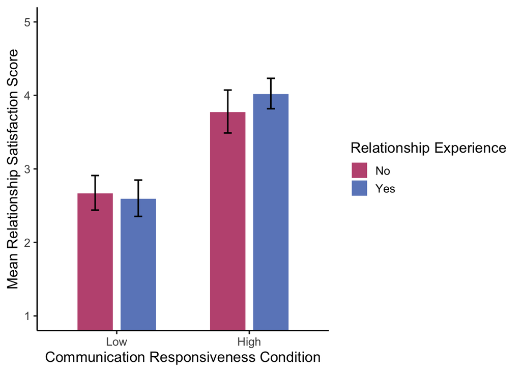

```r
p_ras_relationship_bar <- ggplot(
  as.data.frame(emmeans(a1_ras_relationship, ~ condition * relationship_exp)),
  aes(
    x = condition,
    y = emmean,
    fill = relationship_exp
  )
) +
  geom_col(
    position = position_dodge(width = 0.65),
    width = 0.55,
    color = "white"
  ) +
  geom_errorbar(
    aes(
      ymin = lower.CL,
      ymax = upper.CL
    ),
    position = position_dodge(width = 0.65),
    width = 0.12,
    linewidth = 0.7
  ) +
  labs(
    x = "Communication Responsiveness Condition",
    y = "Mean Relationship Satisfaction Score",
    fill = "Relationship Experience"
  ) +
  scale_fill_manual(
    values = c(
      "No" = "#C05780",   # YOU CAN CHANGE THESE TWO HEX VALUES TO MATCH YOUR POSTER!
      "Yes" = "#6C88C4"
    )
  ) +
  scale_y_continuous(
    breaks = seq(1, 5, 1)
  ) +
  coord_cartesian(
    ylim = c(1, 5)
  ) +
  theme_classic(
    base_size = 14
  )

p_ras_relationship_bar
```

The figure shows estimated relationship satisfaction scores by communication responsiveness condition and relationship experience group, with error bars representing 95% confidence intervals.

### Relationship Satisfaction with Overall Attachment Insecurity Interaction Plot

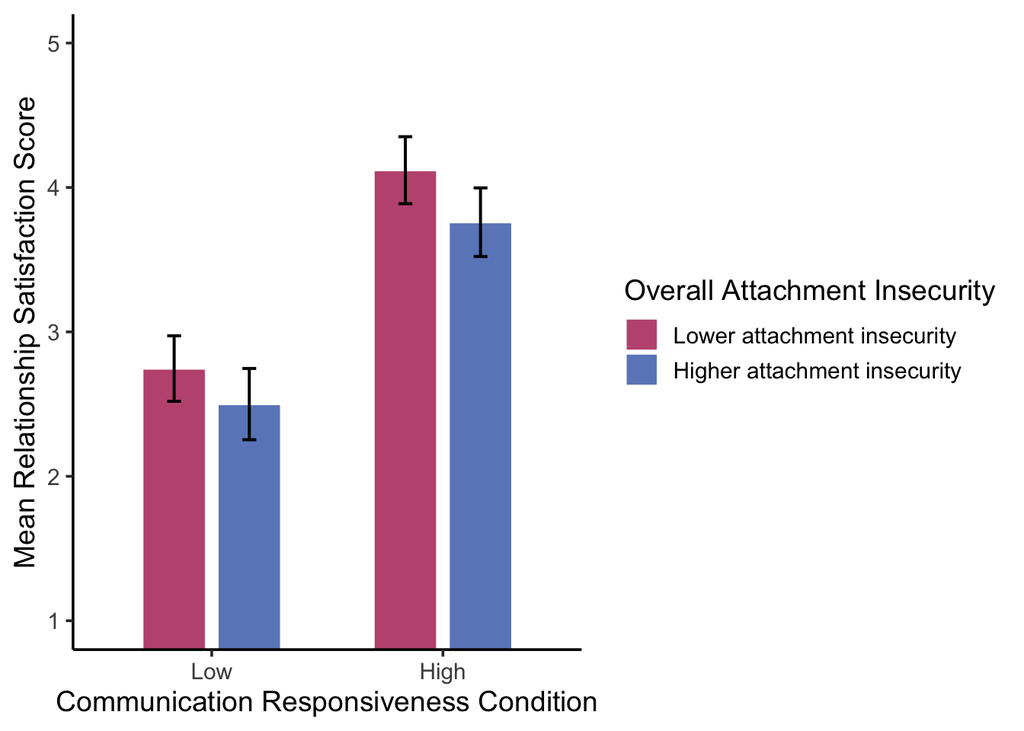

```r
p_ras_aas_total_bar <- ggplot(
  as.data.frame(emmeans(a2_ras_aas_total, ~ condition * aas_total_group)),
  aes(
    x = condition,
    y = emmean,
    fill = aas_total_group
  )
) +
  geom_col(
    position = position_dodge(width = 0.65),
    width = 0.55,
    color = "white"
  ) +
  geom_errorbar(
    aes(
      ymin = lower.CL,
      ymax = upper.CL
    ),
    position = position_dodge(width = 0.65),
    width = 0.12,
    linewidth = 0.7
  ) +
  labs(
    x = "Communication Responsiveness Condition",
    y = "Mean Relationship Satisfaction Score",
    fill = "Overall Attachment Insecurity"
  ) +
  scale_fill_manual(
    values = c(
      "Lower attachment insecurity" = "#C05780",   # YOU CAN CHANGE THESE TWO HEX VALUES TO MATCH YOUR POSTER!
      "Higher attachment insecurity" = "#6C88C4"
    )
  ) +
  scale_y_continuous(
    breaks = seq(1, 5, 1)
  ) +
  coord_cartesian(
    ylim = c(1, 5)
  ) +
  theme_classic(
    base_size = 14
  )

p_ras_aas_total_bar
```

The figure shows estimated relationship satisfaction scores by communication responsiveness condition and overall attachment insecurity group, with error bars representing 95% confidence intervals.

### Relationship Satisfaction with Dependence Insecurity Interaction Plot

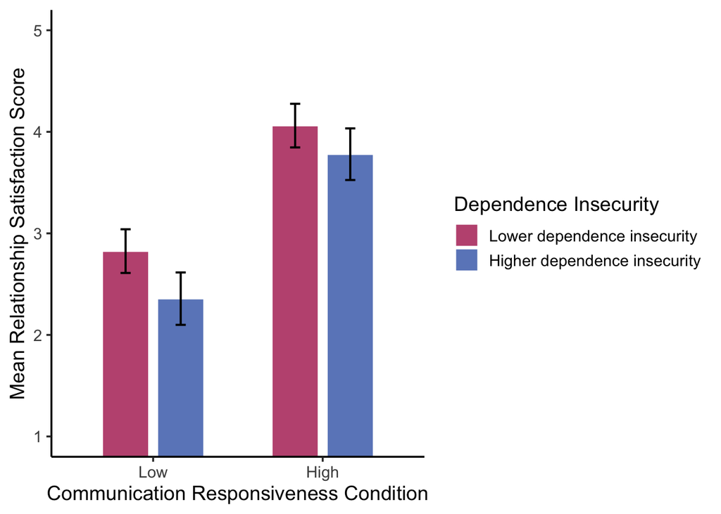

```r
p_ras_aas_depend_bar <- ggplot(
  as.data.frame(emmeans(a3_ras_aas_depend, ~ condition * aas_depend_group)),
  aes(
    x = condition,
    y = emmean,
    fill = aas_depend_group
  )
) +
  geom_col(
    position = position_dodge(width = 0.65),
    width = 0.55,
    color = "white"
  ) +
  geom_errorbar(
    aes(
      ymin = lower.CL,
      ymax = upper.CL
    ),
    position = position_dodge(width = 0.65),
    width = 0.12,
    linewidth = 0.7
  ) +
  labs(
    x = "Communication Responsiveness Condition",
    y = "Mean Relationship Satisfaction Score",
    fill = "Dependence Insecurity"
  ) +
  scale_fill_manual(
    values = c(
      "Lower dependence insecurity" = "#C05780",   # YOU CAN CHANGE THESE TWO HEX VALUES TO MATCH YOUR POSTER!
      "Higher dependence insecurity" = "#6C88C4"
    )
  ) +
  scale_y_continuous(
    breaks = seq(1, 5, 1)
  ) +
  coord_cartesian(
    ylim = c(1, 5)
  ) +
  theme_classic(
    base_size = 14
  )

p_ras_aas_depend_bar
```

The figure shows estimated relationship satisfaction scores by communication responsiveness condition and dependence insecurity group, with error bars representing 95% confidence intervals.

### Relationship Satisfaction with Attachment Anxiety Interaction Plot

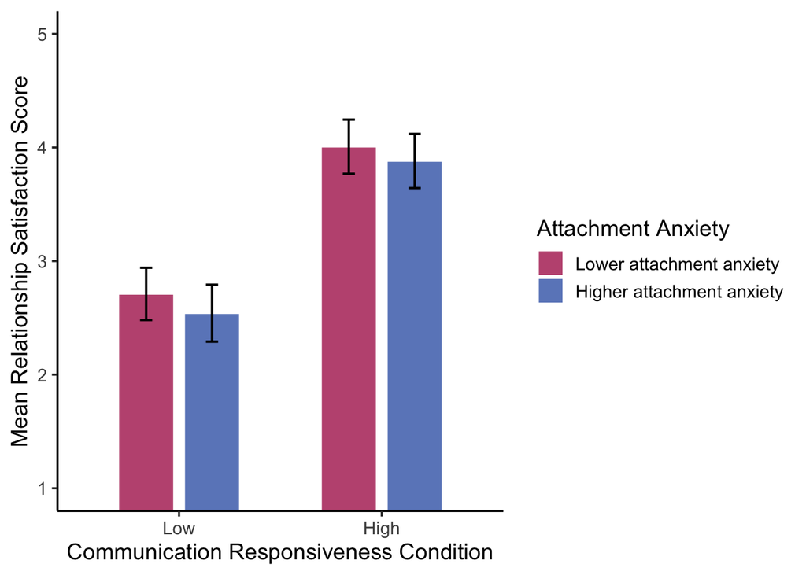

```r
p_ras_aas_anxiety_bar <- ggplot(
  as.data.frame(emmeans(a4_ras_aas_anxiety, ~ condition * aas_anxiety_group)),
  aes(
    x = condition,
    y = emmean,
    fill = aas_anxiety_group
  )
) +
  geom_col(
    position = position_dodge(width = 0.65),
    width = 0.55,
    color = "white"
  ) +
  geom_errorbar(
    aes(
      ymin = lower.CL,
      ymax = upper.CL
    ),
    position = position_dodge(width = 0.65),
    width = 0.12,
    linewidth = 0.7
  ) +
  labs(
    x = "Communication Responsiveness Condition",
    y = "Mean Relationship Satisfaction Score",
    fill = "Attachment Anxiety"
  ) +
  scale_fill_manual(
    values = c(
      "Lower attachment anxiety" = "#C05780",   # YOU CAN CHANGE THESE TWO HEX VALUES TO MATCH YOUR POSTER!
      "Higher attachment anxiety" = "#6C88C4"
    )
  ) +
  scale_y_continuous(
    breaks = seq(1, 5, 1)
  ) +
  coord_cartesian(
    ylim = c(1, 5)
  ) +
  theme_classic(
    base_size = 14
  )

p_ras_aas_anxiety_bar
```

The figure shows estimated relationship satisfaction scores by communication responsiveness condition and attachment anxiety group, with error bars representing 95% confidence intervals.

### Relationship Satisfaction with Closeness Discomfort Interaction Plot

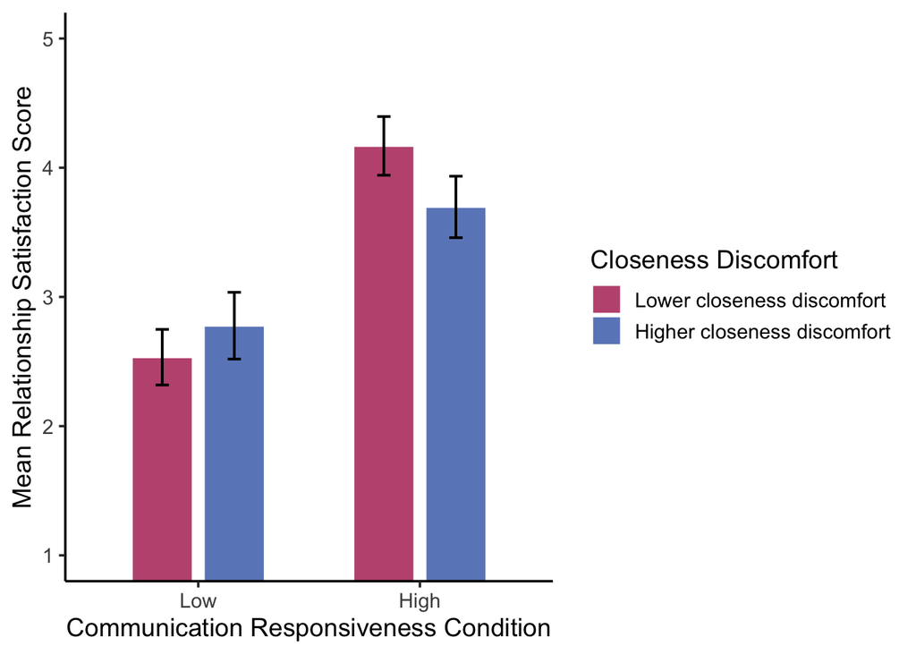

```r
p_ras_aas_close_bar <- ggplot(
  as.data.frame(emmeans(a5_ras_aas_close, ~ condition * aas_close_group)),
  aes(
    x = condition,
    y = emmean,
    fill = aas_close_group
  )
) +
  geom_col(
    position = position_dodge(width = 0.65),
    width = 0.55,
    color = "white"
  ) +
  geom_errorbar(
    aes(
      ymin = lower.CL,
      ymax = upper.CL
    ),
    position = position_dodge(width = 0.65),
    width = 0.12,
    linewidth = 0.7
  ) +
  labs(
    x = "Communication Responsiveness Condition",
    y = "Mean Relationship Satisfaction Score",
    fill = "Closeness Discomfort"
  ) +
  scale_fill_manual(
    values = c(
      "Lower closeness discomfort" = "#C05780",   # YOU CAN CHANGE THESE TWO HEX VALUES TO MATCH YOUR POSTER!
      "Higher closeness discomfort" = "#6C88C4"
    )
  ) +
  scale_y_continuous(
    breaks = seq(1, 5, 1)
  ) +
  coord_cartesian(
    ylim = c(1, 5)
  ) +
  theme_classic(
    base_size = 14
  )

p_ras_aas_close_bar
```

The figure shows estimated relationship satisfaction scores by communication responsiveness condition and closeness discomfort group, with error bars representing 95% confidence intervals.

### Export Figures

```r
if (!dir.exists("figures")) {
  dir.create("figures")
}

ggsave(
  filename = "figures/relationship_satisfaction_relationship_experience_interaction_plot.svg",
  plot = p_ras_relationship_bar,
  width = 7,
  height = 5
)

ggsave(
  filename = "figures/relationship_satisfaction_overall_attachment_insecurity_interaction_plot.svg",
  plot = p_ras_aas_total_bar,
  width = 7,
  height = 5
)

ggsave(
  filename = "figures/relationship_satisfaction_dependence_insecurity_interaction_plot.svg",
  plot = p_ras_aas_depend_bar,
  width = 7,
  height = 5
)

ggsave(
  filename = "figures/relationship_satisfaction_attachment_anxiety_interaction_plot.svg",
  plot = p_ras_aas_anxiety_bar,
  width = 7,
  height = 5
)

ggsave(
  filename = "figures/relationship_satisfaction_closeness_discomfort_interaction_plot.svg",
  plot = p_ras_aas_close_bar,
  width = 7,
  height = 5
)
```

All five 2 x 2 ANOVA model figures were exported to the figures folder for use in the manuscript, poster, or repository materials.

## Results Summary

The Prior Relationship Experience, Attachment Anxiety, and Closeness Discomfort groups were not statistically significant predictors of relationship satisfaction. The interaction between the communication responsiveness condition and prior relationship experience group was also not statistically significant for relationship satisfaction, indicating that the difference between high and low communication responsiveness conditions did not meaningfully vary across prior relationship experience groups.

Next, the interaction between communication responsiveness and overall attachment insecurity was also not statistically significant for relationship satisfaction, indicating that the difference between high and low communication responsiveness conditions did not meaningfully vary across overall attachment insecurity groups.

Secondly, the interaction between communication responsiveness and dependence insecurity was also not statistically significant for relationship satisfaction, indicating that the difference between high and low communication responsiveness conditions did not meaningfully vary across dependence insecurity groups.

Therefore, the interaction between communication responsiveness and attachment anxiety was also not statistically significant for relationship satisfaction, indicating that the difference between high and low communication responsiveness conditions did not meaningfully vary across attachment anxiety groups. The estimated means and interaction plots above provide the full model output and visualize the pattern of results for communication responsiveness, prior relationship experience, relationship satisfaction, and attachment style groups.